# Admir Makas

### STT-6660 HW #4

```python
import numpy as np
import scipy as sp
import sympy as sy
import warnings

%matplotlib inline
import matplotlib.pyplot as plt

sy.init_printing(use_latex='mathjax')
from IPython.display import display, Math, Latex
```

## Problem 1.22

[figure not shown]

### **Part a**

```python
#Define the data

Y = sy.Matrix([199, 205, 196, 200, 218, 220, 215, 223, 237, 234, 235, 230, 250, 248, 253, 246]).T
X = sy.Matrix([16, 16, 16, 16, 24, 24, 24, 24, 32, 32, 32, 32, 40, 40, 40, 40]).T
```

```python
display(X)
display(Y)
```

$$\left[\begin{array}{cccccccccccccccc}16 & 16 & 16 & 16 & 24 & 24 & 24 & 24 & 32 & 32 & 32 & 32 & 40 & 40 & 40 & 40\end{array}\right]$$

$$\left[\begin{array}{cccccccccccccccc}199 & 205 & 196 & 200 & 218 & 220 & 215 & 223 & 237 & 234 & 235 & 230 & 250 & 248 & 253 & 246\end{array}\right]$$

**Calculate mean for X**

```python
Xbar = np.mean(X).evalf(5)
display(Math(r'\bar{X} = '))
display(Xbar)
```

$$\bar{X} = $$

$$28.0$$

**Calculate mean for Y**

```python
Ybar = np.mean(Y).evalf(4)
display(Math(r'\bar{Y} = '))
display(Ybar)
```

$$\bar{Y} = $$

$$225.6$$

**Get $S_{xy}$**

```python
Sxy = np.sum(np.multiply(X,Y)) - (1/16)*(np.sum(X)*np.sum(Y))
display(Math(r'S_{xy} = '))
display(Sxy)
```

$$S_{xy} = $$

$$2604.0$$

**Get $S_{xx}$**

```python
Sxx = np.sum(np.multiply(X,X)) - (1/16)*(np.sum(X)*np.sum(X))
display(Math(r'S_{xx} = '))
display(Sxx)
```

$$S_{xx} = $$

$$1280.0$$

**Get $b_1$**

```python
b1 = (Sxy/Sxx).evalf(5)
display(Math(r'b_{1} = '))
display(b1)
```

$$b_{1} = $$

$$2.0344$$

**Get $b_0$**

```python
b0 = (Ybar - b1*Xbar).evalf(4)
display(Math(r'b_{0} = '))
display(b0)
```

$$b_{0} = $$

$$168.6$$

### **Regression Function is:**

### **$\hat{Y} = 2.0344X + 168.6$**

### **Next plot the data and the corresponding regression model.**

### **From the figure below the regression model fits the data quite well.**

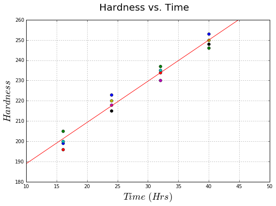

```python
X1=np.linspace(0.0,300.0,500)

Y1 = 2.0344*X1 + 168.6;

fig=plt.figure(1, figsize=(9,6))
ax = fig.add_subplot(111)

ax.plot(X, Y, "o")
ax.plot(X1, Y1)

#Plot annotations
axis_span=[10, 50, 180, 260]
plt.axis(axis_span)
fig.suptitle('Hardness vs. Time', fontsize=20)
plt.xlabel('$Time\ (Hrs)$', fontsize=20)
plt.ylabel('$Hardness$', fontsize=20)
plt.grid()
```

### **Part b**

```python
y_est = (2.0344*40 + 168.6)
display(Math(r'\hat{y_1} = '))
display(y_est)
```

$$\hat{y_1} = $$

$$249.976$$

### **Part c**

```python
y2_est = (2.0344*41 + 168.6)
display(Math(r'\hat{y_2} = '))
display(y2_est)
```

$$\hat{y_2} = $$

$$252.0104$$

**The difference simply ends up being $b_1$ since predictor was increased by a unit value.**

```python
diff = (y2_est) - (y_est)
display(Math(r'\hat{y_2} - \hat{y_1} = '))
diff
```

$$\hat{y_2} - \hat{y_1} = $$

$$2.034400000000005$$

## Problem 2.25

[figure not shown]

### **Part a**

```python
#Define the data

X = sy.Matrix([1, 0, 2, 0, 3, 1, 0, 1, 2, 0]).T
Y = sy.Matrix([16, 9, 17, 12, 22, 13, 8, 15, 19, 11]).T
```

```python
display(X)
display(Y)
```

$$\left[\begin{matrix}1 & 0 & 2 & 0 & 3 & 1 & 0 & 1 & 2 & 0\end{matrix}\right]$$

$$\left[\begin{matrix}16 & 9 & 17 & 12 & 22 & 13 & 8 & 15 & 19 & 11\end{matrix}\right]$$

**Calculate mean for Y**

```python
Ybar = np.mean(Y).evalf(4)
display(Math(r'\bar{Y} = '))
display(Ybar)
```

$$\bar{Y} = $$

$$14.2$$

**Calculate SSTO**

```python
SSTO = (np.sum(np.power((Y-np.ones((1,10))*Ybar),2))).evalf(5)
display(Math(r'SSTO = '))
display(SSTO)
```

$$SSTO = $$

$$177.6$$

**Calculate SSE**

```python
Y_est1 = np.multiply(np.ones((1,10))*4, X)
Y_est = np.add(Y_est1, np.ones((1,10))*10.2)
```

```python
SSE = np.sum(np.power((Y-Y_est),2))
display(Math(r'SSE = '))
display(SSE)
```

$$SSE = $$

$$17.6$$

**Calculate SSR**

```python
SSR = (SSTO-SSE).evalf(6)
display(Math(r'SSR = SSTO - SSE'))
display(SSR)
```

$$SSR = SSTO - SSE$$

$$160.0$$

**Calculate MSE**

```python
MSE = (SSE/8).evalf(5)
display(Math(r'MSE = '))
display(MSE)
```

$$MSE = $$

$$2.2$$

### **Below is the ANOVA table**

[figure not shown]

### **Part b**

**$H_0:\beta_{1} = 0$**  
**$H_a:\beta_{1} \ne 0$**

```python
Fobs = SSR/MSE
display(Math(r'F_{obs} = '))
Fobs
```

$$F_{obs} = $$

$$72.7273$$

```python
display(Math(r'Get\ F(0.95, 1, 8)'))
from scipy.stats import f
f.ppf(0.95, 1, 8)
```

$$Get\ F(0.95, 1, 8)$$

$$5.31765507158$$

**From the above calculation we have**

**$F(0.95, 1, 8) = 5.32$**

**Since $F_{obs} = 72.7273$ $\ge$ $F = 5.32$ and is therefore in the rejection region we conclude that $H_0$ cannot be accepted**

### **Part c**

**Get $S_{xy}$**

```python
Sxy = np.sum(np.multiply(X,Y)) - (1/10)*(np.sum(X)*np.sum(Y))
display(Math(r'S_{xy} = '))
display(Sxy)
```

$$S_{xy} = $$

$$40.0$$

**Get $S_{xx}$**

```python
Sxx = np.sum(np.multiply(X,X)) - (1/10)*(np.sum(X)*np.sum(X))
display(Math(r'S_{xx} = '))
display(Sxx)
```

$$S_{xx} = $$

$$10.0$$

**Get $b_{1}$**

```python
b1 = Sxy/Sxx
display(Math(r'b_{1} = '))
b1
```

$$b_{1} = $$

$$4.0$$

**Get $S_{yy}$**

```python
Syy = np.sum(np.multiply(Y,Y)) - (1/10)*(np.sum(Y)*np.sum(Y))
display(Math(r'S_{yy} = '))
display(Syy)
```

$$S_{yy} = $$

$$177.6$$

**Get $SSE$**

```python
SSE = (Syy).evalf(4) - (b1*Sxy).evalf(4)
display(Math(r'SSE = '))
SSE
```

$$SSE = $$

$$17.6$$

**Finally, get $s^2$**

```python
s2 = (SSE/8).evalf(4)
display(Math(r's^2 = '))
s2
```

$$s^2 = $$

$$2.2$$

```python
t_obs = (b1/(sy.sqrt(s2)/sy.sqrt(Sxx))).evalf(4)
display(Math(r't_{obs} = '))
t_obs
```

$$t_{obs} = $$

$$8.528$$

**$t_{0.95}(8)$ = 2.306**  
**$t_{obs}$ = 8.5280**

**Since $t_{obs}$ $\ge$ $t_{0.95}(8)$, the null hyppothesis cannot be accepted. This is the same result obtained by ANOVA.**

**$(t_{obs})^2$ will yield F as seen below, which demostrated the equivalency between the two methods.**

```python
display(Math(r'(t_{obs})^2 = F_{obs}'))
(t_obs**2).evalf(5)
```

$$(t_{obs})^2 = F_{obs}$$

$$72.729$$

### **Part d**

```python
R2 = (Sxy**2/(Sxx*Syy)).evalf(6)
display(Math(r'R^2 = '))
R2
```

$$R^2 = $$

$$0.900901$$

```python
r = (Sxy/(sy.sqrt(Sxx*Syy))).evalf(4)
display(Math(r'r = '))
r
```

$$r = $$

$$0.9492$$

### **90.09% of the variation is accounted for by introducing X into the regression model.**

## Problem 3.6

[figure not shown]

```python
Y = sy.Matrix([199, 205, 196, 200, 218, 220, 215, 223, 237, 234, 235, 230, 250, 248, 253, 246]).T
X = sy.Matrix([16, 16, 16, 16, 24, 24, 24, 24, 32, 32, 32, 32, 40, 40, 40, 40]).T
```

**Get predicted values**

```python
Yhat = 2.0344*X + 168.6*np.ones((1,16))
```

**Get residuals $e_i$**

```python
e = Y-Yhat
display(Math(r'e_i = '))
e.T.evalf(5)
```

$$e_i = $$

$$\left[\begin{matrix}-2.1504\\3.8496\\-5.1504\\-1.1504\\0.5744\\2.5744\\-2.4256\\5.5744\\3.2992\\0.2992\\1.2992\\-3.7008\\0.024\\-1.976\\3.024\\-3.976\end{matrix}\right]$$

### **Here is the boxplot for the residuals**

```python
e2=np.array(e[:],dtype=float)
```

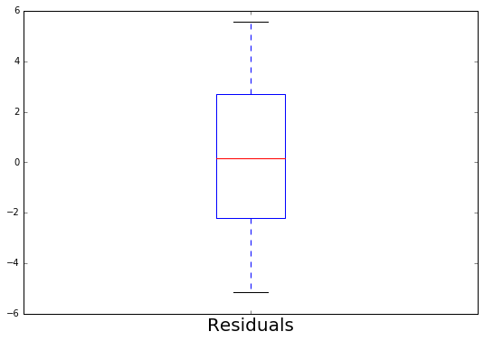

```python
fig = plt.figure(1, figsize=(9, 6))
ax = fig.add_subplot(111)
ax.boxplot(e2)
ax.set_xticklabels(['Residuals'], fontsize=20)
```

### **From the boxplot above, it appears that the residuals are normally distributed**

## **Below is plot of Residuals vs. $\hat{Y}$**

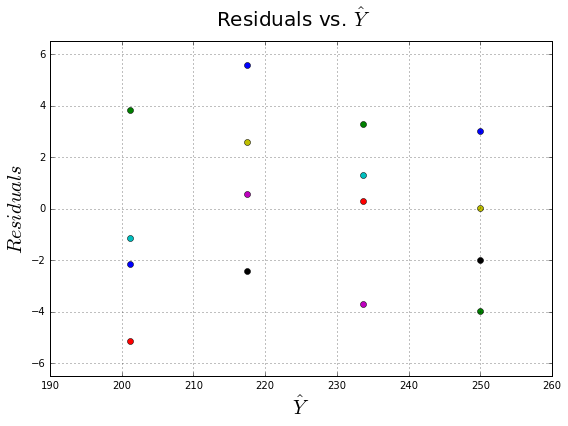

```python
fig=plt.figure(1, figsize=(9, 6))

ax = fig.add_subplot(111)
ax.plot(Yhat, e, "o")

#Plot annotations
axis_span=[190, 260, -6.5, 6.5]
plt.axis(axis_span)

fig.suptitle('Residuals vs. $\hat{Y}$', fontsize=20)
plt.xlabel('$\hat{Y}$', fontsize=20)
plt.ylabel('$Residuals$', fontsize=20)
plt.grid()
```

### **No unusual departures from the X-axis are noticable. The assumption of constant variance seems to apply for this data-set.**